# HW5_Solutuions

Konstantinos Pasvantis

2023-01-15

## [A] Ερωτήσεις σε χωρικά δεδομένα

Φορτώνουμε όλες τις απαραίττητες βιβλιοθήκες που θα μας χρειαστούν

```r
library(tidyverse)
library(cshapes)
library(sf)
```

Επίσης διαβάζουμε από την βιβλιοθήκη cshapes τους παγκόσμιους χάρτες για την ημερομηνία 2019-1-1

```r
cmap.2019<-cshp(date=as.Date("2019-1-1"))
```

Και διορθώνουμε και τα προβληματικά πολύγωνα χωρών

```r
validcmap.2019 <- st_make_valid(cmap.2019)
```

Εδώ όταν χρησιμοποιούσα για τα graphs την γεωμετρία του validcmap.2019, η Ρωσία μου έβγαινε παραμορφωμένη στα περισσότερα, οπότε θα χρησιμοποιώ το cmap.2019, σε όποιο σημείο δεν μου έβγαζε κάποιο πρόβλημα.

### Ερώτημα 1

Αρχικά δημιουργούμε τον πίνακα των αποστάσεων και στην συνέχεια παίρνουμε την γραμμή που αφορά την Ελλάδα (ο κωδικός της COW είναι 350) και ελέγχουμε για ποιές εγγραφές ικανοποιείται η ζητούμενη απαίτηση (εδώ χρησιμοποιήσαμε την ελάχιστη απόσταση μεταξύ των πολυγώνων των χωρών:

```r
dmat <- distmatrix(as.Date("2019-1-1"), type="mindist")
km_logical<-dmat['350',]<2000.0
```

Αφού δημιουργήσαμε το λογικό διάνυσμα km_logical, το χρησιμοπούμε για να επιλέξουμε από το sf_object cmap.2019 τις χώρες οι οποίες απέχουν λιγότερο από 2000 km (εδώ η συνάρτηση distmatrix βγάζει αποτελέσματα σε km οπότε δεν χρειάζεται να κάνουμε κάποια μετατροπή). Τέλος χρησιμοποιώντας την βιβλιοθήκη ggplot κατασκεύάζουμε το γράφημα.

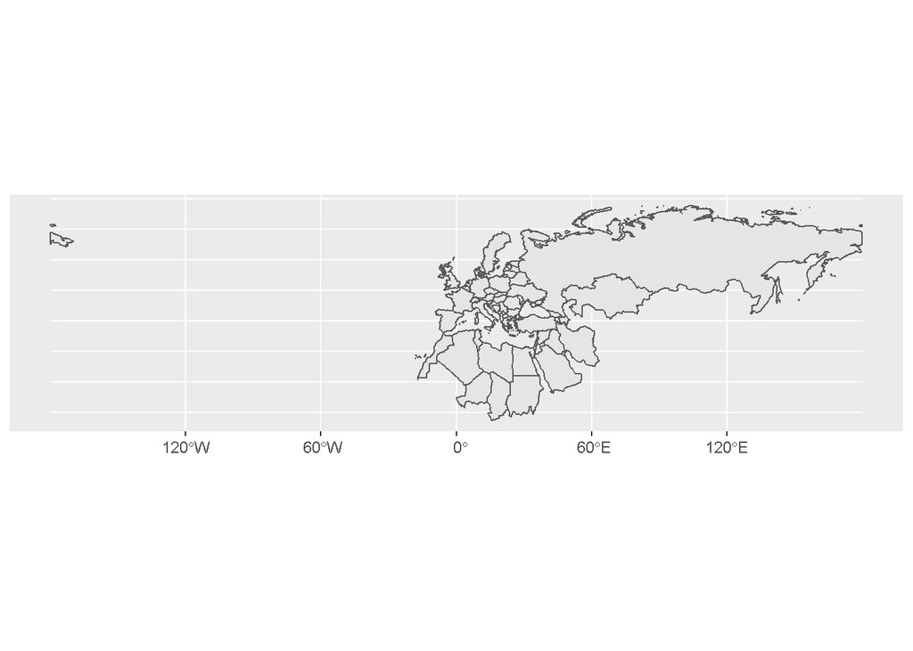

```r
greece_below_2000<-cmap.2019[km_logical,]

a1<-ggplot(greece_below_2000)+geom_sf()
a1
```

### Ερώτημα 2

Για να δημιουργήσoυμε ένα καινούργιο sf_object, διαλέγουμε μόνο τις στήλες που θα μας χρειαστούν από το αρχικό dataset, στην προκειμένη περίπτωση τις στήλες capname, caplong και caplat, οι οποίες περιλαμβάνουν τα ονόματα των προτευουσών, το γεωγραφικό μήκος και το γεωγραφικό πλάτος τους. Στην συγκεκριμένη περίπτωση κάνουμε και drop geometry αφού στα sf αντικείμενα οι γεωμετρίες ακολουθούν οποιοδήποτε υποσύνολο του αρχικού dataframe.

```r
capital_dataframe<- cmap.2019[,c('capname','caplong','caplat')]%>%st_drop_geometry()
head(capital_dataframe)
```

```
##           capname   caplong   caplat
## 3      Washington -77.03667 38.89500
## 9          Ottawa -75.69000 45.42083
## 12         Nassau -77.34300 25.07735
## 14         Havana -82.36417 23.13194
## 17 Port-au-Prince -72.33500 18.53920
## 19  Santo Domingo -69.90000 18.46667
```

Και τώρα δημιουργώ το sf_object χρησιμοποιώντας το WGS84 ως CRS.

```r
capital_sf_object<-st_as_sf(x=capital_dataframe,
                 coords = c('caplong','caplat'),
                 crs='WGS84')
capital_sf_object
```

```
## Simple feature collection with 174 features and 1 field
## Geometry type: POINT
## Dimension:     XY
## Bounding box:  xmin: -99.13861 ymin: -41.3 xmax: 178.4303 ymax: 64.15
## Geodetic CRS:  WGS 84
## First 10 features:
##           capname                   geometry
## 3      Washington   POINT (-77.03667 38.895)
## 9          Ottawa    POINT (-75.69 45.42083)
## 12         Nassau   POINT (-77.343 25.07735)
## 14         Havana POINT (-82.36417 23.13194)
## 17 Port-au-Prince    POINT (-72.335 18.5392)
## 19  Santo Domingo     POINT (-69.9 18.46667)
## 21       Kingston           POINT (-76.8 18)
## 23  Port-of-Spain    POINT (-61.51667 10.65)
## 25     Bridgetown     POINT (-59.61666 13.1)
## 28    Mexico City POINT (-99.13861 19.43417)
```

Βλέπουμε ότι το νέο αντικείμενο sf με τις πρωτεύουσες δημιουργήθηκε σωστά, οπότε τώρα πηγαίνουμε να συνδυάσουμε τα παραπάνω μέσω της ggplot.

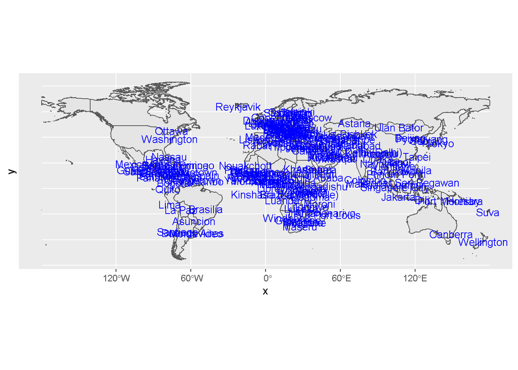

```r
p1<-ggplot(data=cmap.2019)+
  geom_sf()+
  geom_sf(data=capital_sf_object,color='red',size=0.1)+
  geom_sf_text(data=capital_sf_object,aes(label=capname),size=3.5,color='blue')

p1
```

### Ερώτημα 3

Αρχικά δημιουργούμε τον buffer 100 km από τα σημεία των πρωτευουσών (εδώ ο buffer χρησιμοπιέι μέτρα, οπότε τα 100km είναι 100.000m)

```r
buffer<-st_buffer(capital_sf_object$geometry,100000)
buffer
```

```
## Geometry set for 174 features
## Geometry type: POLYGON
## Dimension:     XY
## Bounding box:  xmin: -100.1031 ymin: -42.20849 xmax: 179.3796 ymax: 65.05873
## Geodetic CRS:  WGS 84
## First 5 geometries:
```

```
## POLYGON ((-78.03095 39.37265, -78.03095 39.3624...
```

```
## POLYGON ((-76.98024 45.44425, -76.98444 45.4351...
```

```
## POLYGON ((-76.45631 25.48504, -76.45631 25.5024...
```

```
## POLYGON ((-83.01465 22.45685, -83.00928 22.4566...
```

```
## POLYGON ((-71.87492 17.75311, -71.85713 17.7514...
```

Τώρα δημιουργούμε ένα λογικό διάνυσμα a, το οποίο παίρνει τιμή TRUE, αν το πολύγωνο που δημιουργεί ο buffer 100km τέμνει παραπάνω από ένα πολύγωνα και FALSE διαφορετικά. Προφανώς το πολύγωνο που δημιουργεί ο buffer μίας πρωτεύουσας τέμνει το πολύγωνο της ίδιας της της χώρας, οπότε αν τέμνει 2 και πάνω σημαίνει ότι o buffer περιλαμβάνει έδαφος και άλλης χώρας.

```r
a<-lengths(st_intersects(buffer,validcmap.2019$geometry))>1
a
```

```
##   [1] FALSE  TRUE FALSE FALSE  TRUE FALSE FALSE  TRUE FALSE FALSE  TRUE  TRUE
##  [13]  TRUE  TRUE FALSE  TRUE FALSE FALSE FALSE FALSE FALSE FALSE FALSE FALSE
##  [25]  TRUE  TRUE  TRUE  TRUE FALSE FALSE  TRUE  TRUE  TRUE  TRUE FALSE  TRUE
##  [37] FALSE FALSE  TRUE FALSE  TRUE  TRUE  TRUE  TRUE FALSE  TRUE  TRUE  TRUE
##  [49]  TRUE  TRUE  TRUE  TRUE  TRUE  TRUE FALSE FALSE  TRUE  TRUE  TRUE FALSE
##  [61]  TRUE  TRUE  TRUE  TRUE FALSE  TRUE  TRUE FALSE  TRUE FALSE  TRUE  TRUE
##  [73] FALSE FALSE  TRUE  TRUE  TRUE FALSE FALSE  TRUE FALSE  TRUE FALSE  TRUE
##  [85] FALSE  TRUE  TRUE FALSE  TRUE FALSE FALSE  TRUE  TRUE  TRUE  TRUE  TRUE
##  [97] FALSE FALSE FALSE  TRUE  TRUE FALSE  TRUE FALSE  TRUE FALSE  TRUE  TRUE
## [109] FALSE  TRUE FALSE FALSE  TRUE  TRUE  TRUE FALSE FALSE FALSE FALSE FALSE
## [121] FALSE FALSE FALSE FALSE FALSE FALSE FALSE FALSE  TRUE  TRUE  TRUE  TRUE
## [133] FALSE FALSE  TRUE  TRUE  TRUE FALSE FALSE  TRUE  TRUE  TRUE  TRUE  TRUE
## [145] FALSE FALSE FALSE FALSE FALSE  TRUE FALSE FALSE  TRUE  TRUE  TRUE FALSE
## [157] FALSE FALSE  TRUE FALSE  TRUE  TRUE FALSE FALSE  TRUE  TRUE FALSE FALSE
## [169]  TRUE FALSE FALSE FALSE FALSE FALSE
```

Εδώ πέρα βλέπουμε ότι χρησιμοποίησαμε το validcmap.2019 αφόυ αν χρησιμοποιούσαμε το cmap.2019 εμφάνιζε error.

Κάνουμε append αυτό το διάνυσμα σαν μεταβλητή στο sf_object με όνομα overlapping_buffer, και στην συνέχεια για να δημιουργήσουμε το ζητούμενο graph, κάνουμε filter τις εγγραφές εκείνες που έχουμε τιμή overlapping_buffer=TRUE.

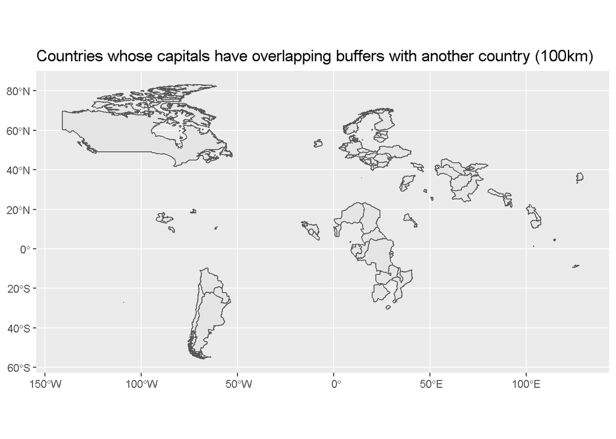

```r
cmap.2019<-cmap.2019%>%add_column(overlapping_buffer=a)

cmap.2019%>%filter(overlapping_buffer==TRUE)%>%
  ggplot()+geom_sf()+ggtitle('Countries whose capitals have overlapping buffers with another country (100km)')
```

Τέλος, βγάζουμε την στήλη overlapping_buffer.

```r
cmap.2019<-cmap.2019[,-c(13)]
```

### Ερώτημα 4

Φτιάχνουμε ένα νέο αντικείμενο sf που ως γεωμετρίες θα έχει τα σημεία των centroid κάθε πολυγώνου

```r
map_cents=st_centroid(validcmap.2019,of_largest=TRUE,crs='WGS84')
map_cents
```

```
## Simple feature collection with 174 features and 11 fields
## Geometry type: POINT
## Dimension:     XY
## Bounding box:  xmin: -103.6404 ymin: -41.7279 xmax: 178.4573 ymax: 65.99113
## Geodetic CRS:  WGS 84
## First 10 features:
##    gwcode             country_name      start        end      status owner
## 3       2 United States of America 1959-08-21 2019-12-31 independent     2
## 9      20                   Canada 1948-07-22 2019-12-31 independent    20
## 12     31                  Bahamas 1973-07-10 2019-12-31 independent    31
## 14     40                     Cuba 1902-05-20 2019-12-31 independent    40
## 17     41                    Haiti 1934-08-15 2019-12-31 independent    41
## 19     42       Dominican Republic 1886-01-01 2019-12-31 independent    42
## 21     51                  Jamaica 1962-08-06 2019-12-31 independent    51
## 23     52      Trinidad and Tobago 1962-08-31 2019-12-31 independent    52
## 25     53                 Barbados 1966-11-30 2019-12-31 independent    53
## 28     70                   Mexico 1886-01-01 2019-12-31 independent    70
##           capname   caplong   caplat b_def fid                   geometry
## 3      Washington -77.03667 38.89500     1   3 POINT (-103.6404 44.76092)
## 9          Ottawa -75.69000 45.42083     1   9  POINT (-96.5153 60.43672)
## 12         Nassau -77.34300 25.07735     1  12 POINT (-76.51007 24.19069)
## 14         Havana -82.36417 23.13194     1  14 POINT (-79.00606 21.63604)
## 17 Port-au-Prince -72.33500 18.53920     1  17 POINT (-72.67999 18.94093)
## 19  Santo Domingo -69.90000 18.46667     1  19  POINT (-70.4845 18.89529)
## 21       Kingston -76.80000 18.00000     1  21 POINT (-77.31826 18.15201)
## 23  Port-of-Spain -61.51667 10.65000     1  23 POINT (-61.25537 10.46614)
## 25     Bridgetown -59.61666 13.10000     1  25 POINT (-59.56226 13.17869)
## 28    Mexico City -99.13861 19.43417     1  28 POINT (-102.1803 23.92671)
```

Και τώρα για να βρούμε την απόσταση μεταξύ κάθε πρωτεύουσας από το centroid της χώρας της θα χρησιμοποιήσουμε την εντολή st_distance. Αν την χρησιμοποιούσαμε για τις γεωμετρίες των map_cents και της γεωμετρίες του capital_sf_object, θα έβγαινε ένας πίνακας 174x174 (174 είναι και οι χώρες) ο οποίος θα υπολόγιζε τις αποστάσεις κάθε centroid από κάθε πρωτεύουσα, κάτι το οποίο δεν θέλουμε. Οπότε, χρησιμοποιούμε την συνάρτηση αυτή βαθμωτά, για μια γραμμή την φορά.

```r
distances_centroids_capitals<-sapply(1:length(map_cents$geometry),function(i)st_distance(map_cents$geometry[i],capital_sf_object$geometry[i]))
head(distances_centroids_capitals)
```

```
## [1] 2287096.55 2157052.04  129645.05  383228.47   57576.92   77860.27
```

Οπότε με το ίδιο σκεπτικό όπως το ερώτημα 3, κάνουμε append αυτή την στήλη που υπολογίσαμε στο cmap.2019. Μετά δημιουργούμε ακόμα μία νέα στήλη η οποία θα παίρνει την τιμή 1, αν η απόσταση μεταξύ κεντροειδών και πρωτευουσών είναι μικρότερη των 100 km, 3 αν η απόσταση είναι μεγαλύτερη των 300km και 2 διαφορετικά.

```r
cmap.2019<-cmap.2019%>%
  add_column(distances=distances_centroids_capitals)%>%
  mutate(category=case_when(distances<100000~'1',
                            distances<=300000~'2',
                            distances>300000~'3'))%>%
  arrange(desc(distances))
cmap.2019
```

```
## Simple feature collection with 174 features and 13 fields
## Geometry type: MULTIPOLYGON
## Dimension:     XY
## Bounding box:  xmin: -180 ymin: -55.90223 xmax: 180 ymax: 83.11387
## Geodetic CRS:  WGS 84
## First 10 features:
##    gwcode                          country_name      start        end
## 1     365                 Russia (Soviet Union) 2014-03-18 2019-12-31
## 2       2              United States of America 1959-08-21 2019-12-31
## 3      20                                Canada 1948-07-22 2019-12-31
## 4     900                             Australia 1927-05-09 2019-12-31
## 5     850                             Indonesia 2002-05-20 2019-12-31
## 6     710                                 China 1950-10-02 2019-12-31
## 7     541                            Mozambique 1975-06-25 2019-12-31
## 8     615                               Algeria 1962-07-05 2019-12-31
```

[output cut: 24 more lines]

Και τώρα είμαστε σε σημείο για να δώσουμε το graph και στην συνέχεια διαγράφουμε και την στήλη category και distances

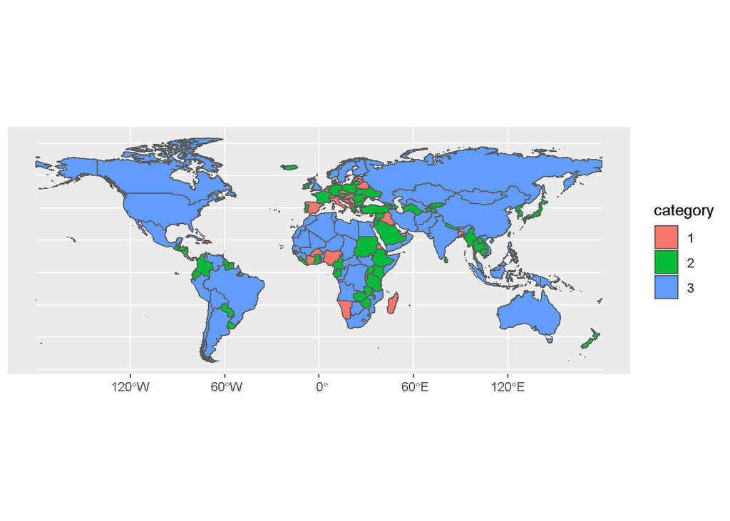

```r
ggplot(data=cmap.2019,aes(fill=category))+geom_sf()
```

```r
cmap.2019<-cmap.2019[,-c(12,13)]
```

### Ερώτημα 5

Εδώ εφόσον έχουμε το αντικείμενο capital_sf_object, θα πάρουμε την εντολή st_distance για να υπολογίσουμε την απόσταση κάθε πρωτεύουσας από κάθε άλλης (στο τελικό αποτέλεσμα εμφανίζουμε τις πρώτες 5 στήλες για εξοικονόμηση χώρου).

```r
distances_between_capitals=st_distance(capital_sf_object,capital_sf_object)
row.names(distances_between_capitals)<-capital_dataframe$capname
colnames(distances_between_capitals)<-capital_dataframe$capname
head(distances_between_capitals[,1:5])
```

```
## Units: [m]
##                Washington  Ottawa    Nassau    Havana Port-au-Prince
## Washington              0  734050 1536723.7 1823879.2      2308514.8
## Ottawa             734050       0 2266938.6 2550888.3      3005136.8
## Nassau            1536724 2266939       0.0  553590.8       891847.5
## Havana            1823879 2550888  553590.8       0.0      1160144.9
## Port-au-Prince    2308515 3005137  891847.5 1160144.9            0.0
## Santo Domingo     2373729 3044563 1063004.9 1394847.2       256888.1
```

## [B] Ερωτήσεις σε δεδομένα δικτύου.

Για τα επόμενα ερωτήματα θα μας χρειαστούν κάποιες επιπλέον βιβλιοθήκες

```r
library(prioritizr)
library(tidygraph)
library(ggraph)
```

### Ερώτημα 1

Χρησιμοποιούμε από την αρχή το αντικείμενο για την ημερομηνία 2019-1-1 και αυτή τη φορά θα το χρησιμοποιήσουμε σαν ένα κανονικό dataframe, αφού κάνουμε drop την στήλη με τις γεωμετρίες.

```r
cmap.2019<-cshp(date=as.Date("2019-1-1"))
cmap.2019<-cmap.2019%>%st_drop_geometry()
```

Για να μην χαλάσουμε το αρχικό μας dataframe θα χρησιμοποιήσουμε ένα νέο. Θέλουμε να δημιουργήσουμε μία νέα μεταβλητή με τις πρωτεύουσες των χωρών που εφάπτονται των παρατηρήσεών μας. Την δημιουργούμε αναθέτοντας την τιμή ΝΑ αρχικά.

```r
newcmap.2019<-cmap.2019
newcmap.2019$going_capitals=NA
```

Δημιουργούμε το proximity matrix με απόσταση 0, δηλαδή υπολογίζει τις χώρες που έχουν απόσταση 0 από τις ζητούμενες,ή αλλιώς τις χώρες οι οποίες εφάπτονται μεταξύ τους.

```r
prox_matrix_countries<-proximity_matrix(validcmap.2019,0)
```

Ο παρακάτω κώδικας κάνει χρήση των for loops για να παράγει για κάθε παρατήρηση του dataframe μας, τις ζητούμενες πρωτεύουσες. Δημιουργούμε για κάθε παρατήρηση ένα διάνυσμα x, το οποίο αποθηκεύει κάθε φορά τις πρωτεύουσες των χωρών οι οποίες εφάπτονται, με χρήση του proximity matrix, και στην συνέχεια αποθηκεύει αυτό το διάνυσμα στην στήλη going_capitals που δημιουργήσαμε. Η νέα στήλη φαίνεται παρακάτω:

```r
for (i in 1:length(newcmap.2019$country_name)){
  x=c()
  for (j in 1:length(newcmap.2019$country_name)){
      if (prox_matrix_countries[i,j]==1){
        x<-append(x,newcmap.2019[j,'capname'])}
    newcmap.2019[i,'going_capitals']=tibble(list(x))

  }
}
head(newcmap.2019$going_capitals)
```

```
## [[1]]
## [1] "Ottawa"      "Mexico City"
##
## [[2]]
## [1] "Washington"
##
## [[3]]
## NULL
##
## [[4]]
## NULL
##
## [[5]]
## [1] "Santo Domingo"
##
## [[6]]
## [1] "Port-au-Prince"
```

Βλέπουμε ότι υπάρχουν χώρες που δεν εφάπτονται με άλλες γειτονικές χώρες κυρίως γιατί είναι νησιά, οπότε δεν θα μας είναι χρήσιμες στο δίκτυο που θα κάνουμε, και έτσι τις διώχνουμε. Επίσης βγάζουμε όλες τις στήλες οι οποίες δεν θα μας χρειαστούν.

```r
newcmap.2019<-newcmap.2019[,-c(1,2,3,4,5,6,8,9,10,11)]
newcmap.2019<-drop_na(newcmap.2019)
head(newcmap.2019)
```

```
##          capname                       going_capitals
## 1     Washington                  Ottawa, Mexico City
## 2         Ottawa                           Washington
## 3 Port-au-Prince                        Santo Domingo
## 4  Santo Domingo                       Port-au-Prince
## 5    Mexico City Washington, Belmopan, Guatemala City
## 6       Belmopan          Mexico City, Guatemala City
```

Και τώρα χρησιμοποιώντας την εντολή unnest, σχηματίζουμε την μορφή που χρειαζόμαστε

```r
newcmap.2019<-newcmap.2019%>%unnest('going_capitals')
newcmap.2019
```

```
## # A tibble: 612 x 2
##    capname        going_capitals
##    <chr>          <chr>
##  1 Washington     Ottawa
##  2 Washington     Mexico City
##  3 Ottawa         Washington
##  4 Port-au-Prince Santo Domingo
##  5 Santo Domingo  Port-au-Prince
##  6 Mexico City    Washington
##  7 Mexico City    Belmopan
##  8 Mexico City    Guatemala City
##  9 Belmopan       Mexico City
## 10 Belmopan       Guatemala City
## # ... with 602 more rows
```

Στην συνέχεια δημιουργούμε μία νέα στήλη με τις αποστάσεις μεταξύ των πρωτευουσών, χρησιμοποιώντας τον πίνακα που είχαμε χρησιμοποιήσει στο πρώτο μέρος της εργασίας, distances_between_capitals.

```r
newcmap.2019$distances=NA
for (i in 1:length(newcmap.2019$capname)){
  newcmap.2019$distances[i]<-distances_between_capitals[newcmap.2019$capname[i],newcmap.2019$going_capitals[i]]
}
head(newcmap.2019)
```

```
## # A tibble: 6 x 3
##   capname        going_capitals distances
##   <chr>          <chr>              <dbl>
## 1 Washington     Ottawa           734050.
## 2 Washington     Mexico City     3031202.
## 3 Ottawa         Washington       734050.
## 4 Port-au-Prince Santo Domingo    256888.
## 5 Santo Domingo  Port-au-Prince   256888.
## 6 Mexico City    Washington      3031202.
```

Τέλος, κάνουμε τον τελικό καθαρισμό που χρειάζεται, δηλαδή μετατρέπουμε τις αποστάσεις απο m σε km, και ονομάζουμε τις στήλες capname και going_capitals σε from και to αντίστοιχα. Μετά από αυτό, δημιουργούμε το ζητούμενο δίκτυο.

```r
newcmap.2019<-newcmap.2019%>%mutate(distances=distances/1000)%>%rename(from=capname,to=going_capitals)

capital_graph<-as_tbl_graph(newcmap.2019)

capital_graph
```

```
## # A tbl_graph: 151 nodes and 612 edges
## #
## # A directed simple graph with 4 components
## #
## # Node Data: 151 x 1 (active)
##   name
##   <chr>
## 1 Washington
## 2 Ottawa
## 3 Port-au-Prince
## 4 Santo Domingo
## 5 Mexico City
## 6 Belmopan
## # ... with 145 more rows
## #
## # Edge Data: 612 x 3
##    from    to distances
##   <int> <int>     <dbl>
## 1     1     2      734.
## 2     1     5     3031.
## 3     2     1      734.
## # ... with 609 more rows
```

### Ερώτημα 2

Χρησιμοποιούμε το θέμα το οποίο εμφανίζεται και στην ιστοσελίδα που χρησιμοποιήσαμε, https://rviews.rstudio.com/2019/03/06/intro-to-graph-analysis/.

```r
thm <- theme_minimal() +
  theme(
    legend.position = "none",
    axis.title = element_blank(),
    axis.text = element_blank(),
    panel.grid = element_blank(),
    panel.grid.major = element_blank(),
  )

theme_set(thm)
```

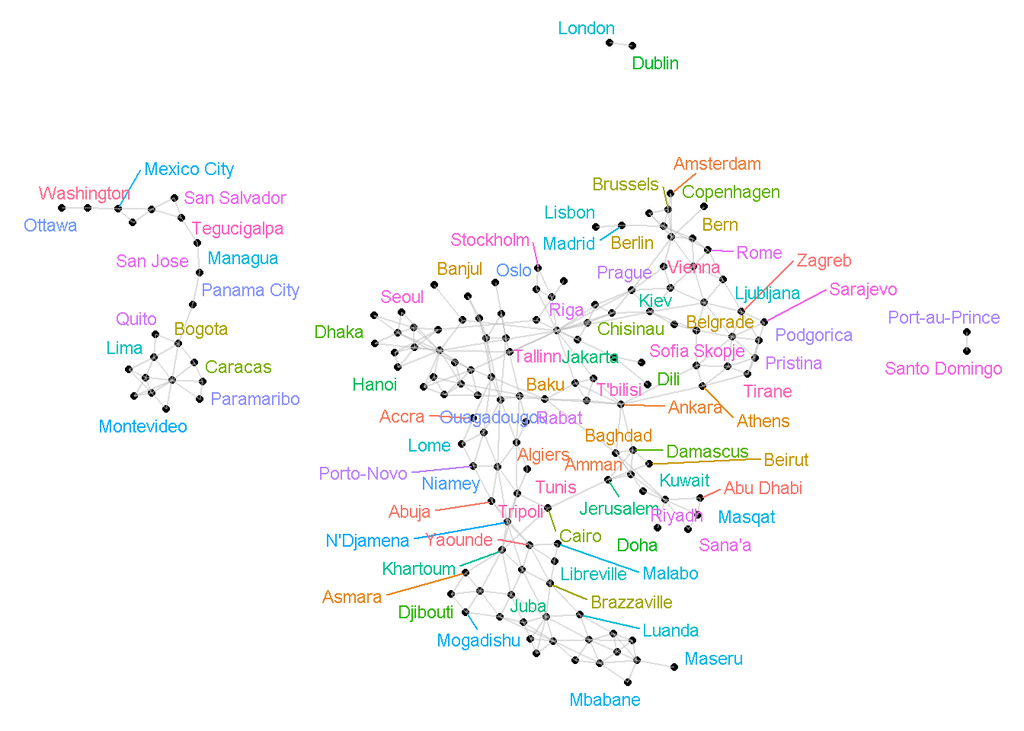

```r
capital_graph%>%ggraph(layout = 'graphopt')+geom_node_point()+
  geom_edge_link(color='gray',alpha=0.3)+geom_node_text(mapping=aes(label=name,color=name),size=3,repel=TRUE)
```

Εδώ επειδή η εικόνα είναι σχετικά μικρή, βλέπουμε ότι με την εντολή repel, η οποία απομακρύνει τα κείμενα των κόμβων αν υπερκαλύπτονται, δεν ονομάζονται όλοι οι κόμβοι! Αυτό μπορούσαμε να το αλλάξουμε αν βγάζαμε την εντολή repel, αλλά το αποτέλεσμα δεν θα ήταν το ίδιο αισθητικά.

### Ερώτημα 3

Στα παρακάτω προβλήματα θα χρησιμοποιήσουμε τον ίδιο κώδικα για να βρούμε τις μικρότερες διαδρομές μεταξύ Αθήνας και Κοπεγχάγης. Πρώτα από όλα πρέπει να μπορούμε να χρησιμοποιήσουμε κάθε φορά τους πίνακες που χρειαζόμαστε, κάτι το οποίο το κάνουμε με την εντολή activate.

```r
capital_graph <- capital_graph%>%
  activate(nodes) %>%
  mutate(
    title = str_to_title(name),
    label = str_replace_all(title, " ", "\n")
  )
```

Στην συνέχεια ονομάζουμε τον πίνακα των nodes capitals

```r
capitals <- capital_graph %>%
  activate(nodes)%>%
  pull(title)
head(capitals)
```

```
## [1] "Washington"     "Ottawa"         "Port-Au-Prince" "Santo Domingo"
## [5] "Mexico City"    "Belmopan"
```

#### (α)

Για να βρούμε την μικρότερη διαδρομή λαμβάνοντας υπόψη τις αποστάσεις μεταξύ κόμβων, δουλεύουμε ως εξής:  
Αρχικά ονομάζουμε τους κόμβους αρχής και τέλους της διαδρομής.

```r
from <- which(capitals == "Athens")
to <-  which(capitals == "Copenhagen")
```

Και τώρα χρησιμοποιώντας την συνάρτηση to_shortest_path λέμε στο δίκτυο που σχηματίστηκε να βρει ποιοί κόμβοι ανήκουν στο συντομότερο μονοπάτι

```r
shortest_weighted <- capital_graph %>%
  morph(to_shortest_path, from, to, weights = distances)
```

Στην συνέχεια δημιουργούμε μία νέα στήλη για να μας βοηθήσει να χρησιμοποιήσουμε μόνο τους κόμβους που χρειαζόμαστε για το συντομότερο μονοπάτι, και αφού κάνουμε activate και τις ακμές, κρατάμε μόνο αυτές που χρειαζόμαστε.

```r
shortest_weighted <- shortest_weighted%>%
  mutate(selected_node = TRUE) %>%
  activate(edges) %>%
  mutate(selected_edge = TRUE) %>%
  unmorph()
```

Τέλος, για τους κόμβους που χρειαζόμαστε τους δίνουμε την τιμή 2, και στους κόμβους τους οποίους δεν χρειαζόμαστε τους δίνουμε την τιμή 1.5 (αυτό για να μας βοηθήσει μετά στο γράφημα)

```r
shortest_weighted <- shortest_weighted %>%
  activate(nodes) %>%
  mutate(selected_node = ifelse(is.na(selected_node), 1.5, 2)) %>%
  activate(edges) %>%
  mutate(selected_edge = ifelse(is.na(selected_edge), 1.5, 2)) %>%
  arrange(selected_edge)
```

Αφού κάναμε την παραπάνω επεξεργασία, πηγαίνουμε να σχηματίσουμε το γράφημα.

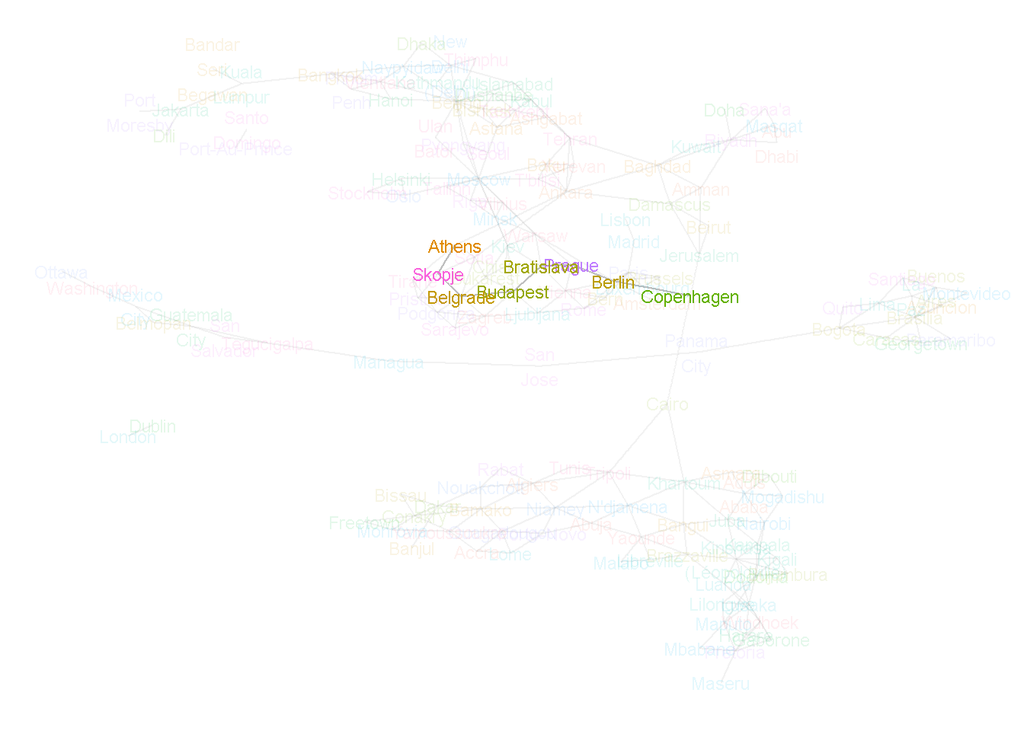

```r
shortest_weighted %>%
  ggraph(layout = "graphopt") +
  geom_edge_link(aes(alpha = selected_edge), color = "gray") +
  geom_node_text(aes(label = label, color =name, alpha = selected_node ), size = 3)
```

```r
shortest_normal <- capital_graph %>%
  morph(to_shortest_path, from, to)

shortest_normal %>%
  mutate(selected_node = TRUE) %>%
  unmorph()
```

```
## # A tbl_graph: 151 nodes and 612 edges
## #
## # A directed simple graph with 4 components
## #
## # Node Data: 151 x 4 (active)
##   name           title          label            selected_node
##   <chr>          <chr>          <chr>            <lgl>
## 1 Washington     Washington     "Washington"     NA
## 2 Ottawa         Ottawa         "Ottawa"         NA
## 3 Port-au-Prince Port-Au-Prince "Port-Au-Prince" NA
## 4 Santo Domingo  Santo Domingo  "Santo\nDomingo" NA
## 5 Mexico City    Mexico City    "Mexico\nCity"   NA
## 6 Belmopan       Belmopan       "Belmopan"       NA
## # ... with 145 more rows
## #
## # Edge Data: 612 x 3
##    from    to distances
##   <int> <int>     <dbl>
## 1     1     2      734.
## 2     1     5     3031.
## 3     2     1      734.
## # ... with 609 more rows
```

```r
shortest_normal <- shortest_normal%>%
  mutate(selected_node = TRUE) %>%
  activate(edges) %>%
  mutate(selected_edge = TRUE) %>%
  unmorph()


shortest_normal <- shortest_normal %>%
  activate(nodes) %>%
  mutate(selected_node = ifelse(is.na(selected_node), 1, 2)) %>%
  activate(edges) %>%
  mutate(selected_edge = ifelse(is.na(selected_edge), 1, 2)) %>%
  arrange(selected_edge)

shortest_normal
```

```
## # A tbl_graph: 151 nodes and 612 edges
## #
## # A directed simple graph with 4 components
## #
## # Edge Data: 612 x 4 (active)
##    from    to distances selected_edge
##   <int> <int>     <dbl>         <dbl>
## 1     1     2      734.             1
## 2     1     5     3031.             1
## 3     2     1      734.             1
## 4     3     4      257.             1
## 5     4     3      257.             1
## 6     5     1     3031.             1
## # ... with 606 more rows
## #
## # Node Data: 151 x 4
##   name           title          label          selected_node
##   <chr>          <chr>          <chr>                  <dbl>
## 1 Washington     Washington     Washington                 1
## 2 Ottawa         Ottawa         Ottawa                     1
## 3 Port-au-Prince Port-Au-Prince Port-Au-Prince             1
## # ... with 148 more rows
```

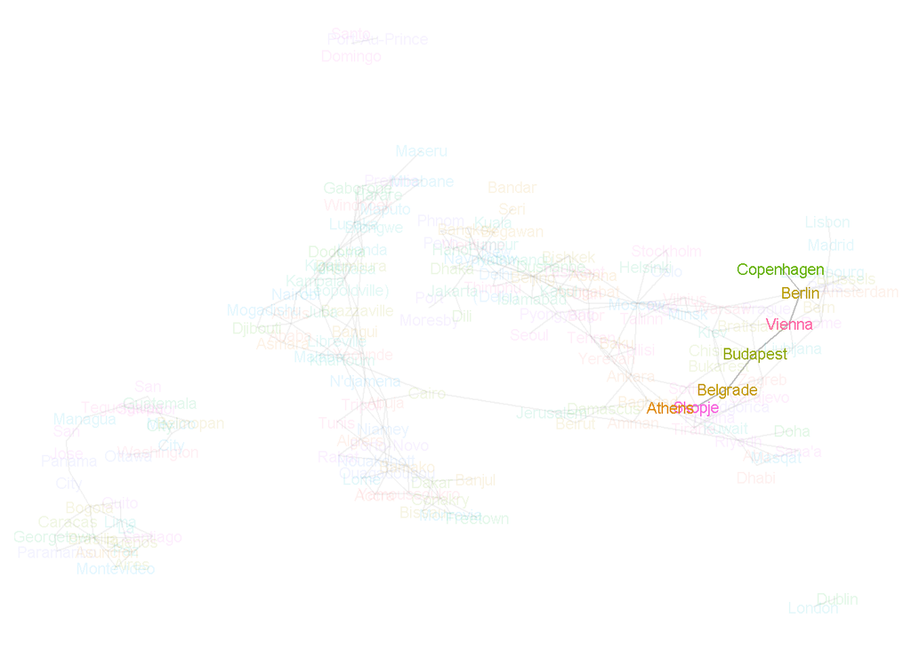

```r
shortest_normal %>%
  ggraph(layout = "graphopt") +
  geom_edge_link(aes(alpha = selected_edge), color = "gray") +
  geom_node_text(aes(label = label, color =name, alpha = selected_node ), size = 3)
```

Εδώ βλέπουμε ότι στο μόνο πράγμα που διαφοροποιείται η διαδρομή είναι ότι από Βουδαπέστη πηγαίνουμε Βιέννη και μετά Βερολίνο, ενώ πριν πηγαίναμε από Βουδαπέστη πρώτα Μπρατισλάβα, μετά Πράγα και μετά Βερολίνο.  
Προσωπικά θα διάλεγα την διαδρομή που περνάει από την Βιέννη, παρόλο που θα έκανα περισσότερα χιλιόμετρα για να φτάσω στην Κοπεγχάγη.